# TCC Statistics with R-A Beginner’s Perspective

#### Histograms

- histogram displays data values on the x-axis against their frequencies on the y-axis allowing you to judge the distribution of the data.
- base R: `hist()`

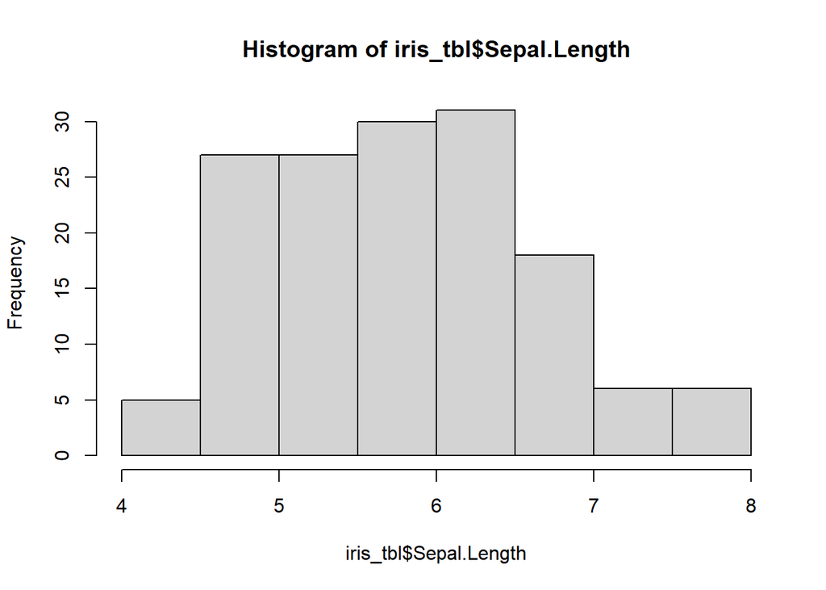

```r
hist(iris_tbl$Sepal.Length)
```

- Let’s use a pretty graphics: `ggplot2` package

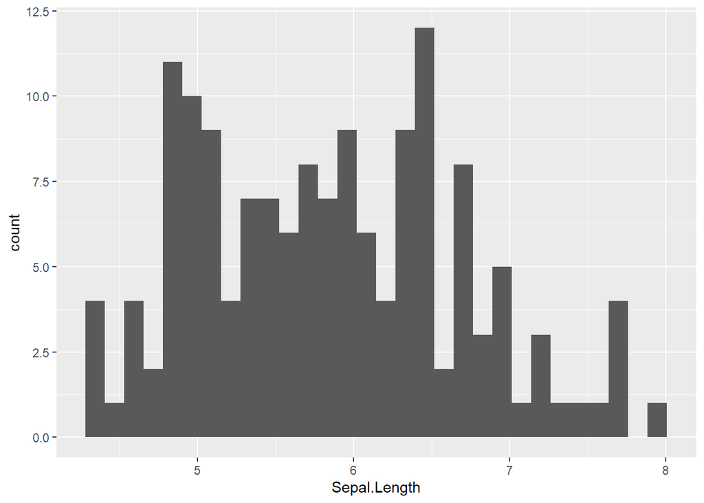

```r
ggplot(iris_tbl) +
  geom_histogram(aes(Sepal.Length))
```

#### Boxplots

- Display continuous data separated into the levels (groups) of a factor (grouping variable)

Note: the bars (“whiskers”) are the are the range of the data that is within 1.5 times the inter-quartile distance from the median. Data points outside that range are regarded as outliers and are displayed as circles.

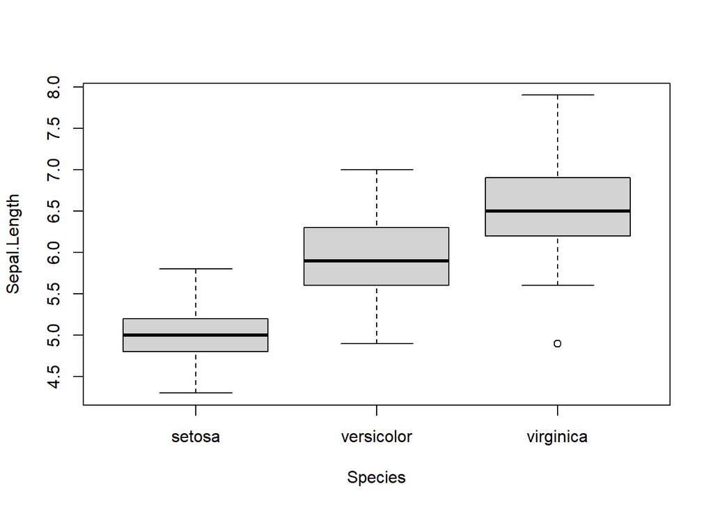

```r
boxplot(Sepal.Length~Species, data=iris_tbl)
```

### Descriptive Statistics

- Another quick way to explore data is to use the command summary(name.of.data.frame).
  - This command gives you a number of descriptive statistics for each continuous variable (range, quartiles, mean, median)
  - For categorical variable, only count per factor level is printed out.

```r
summary(iris_tbl)
```

```
##   Sepal.Length    Sepal.Width     Petal.Length    Petal.Width
##  Min.   :4.300   Min.   :2.000   Min.   :1.000   Min.   :0.100
##  1st Qu.:5.100   1st Qu.:2.800   1st Qu.:1.600   1st Qu.:0.300
##  Median :5.800   Median :3.000   Median :4.350   Median :1.300
##  Mean   :5.843   Mean   :3.057   Mean   :3.758   Mean   :1.199
##  3rd Qu.:6.400   3rd Qu.:3.300   3rd Qu.:5.100   3rd Qu.:1.800
##  Max.   :7.900   Max.   :4.400   Max.   :6.900   Max.   :2.500
##        Species
##  setosa    :50
##  versicolor:50
##  virginica :50
##
##
##
```

- Or use the commands:
  - mean -> `mean(variable.name)`
  - median -> `median(variable.name)`
  - range -> `range(variable.name)`
  - standard deviation -> `sd(variable.name)`
  - no. of observations -> `length(variable.name)`
  - variance -> `var(variable.name)`

#### Calculating descriptive statistics for groups of data

- use `tapply()` -> `tapply(X=variable.name,INDEX=list(variable.name), FUN=command.name)`

```r
tapply(X=iris_tbl$Sepal.Length, INDEX=list(iris_tbl$Species), FUN=mean)
```

```
##     setosa versicolor  virginica
##      5.006      5.936      6.588
```

- Or, use `summarise()` and `group_by()`

```r
(iris_species_sepal.length_summary <- iris_tbl %>%
  group_by(Species) %>%
  summarise(averageSepalLength = mean(Sepal.Length)) %>%
  ungroup())
```

```
## # A tibble: 3 x 2
##   Species    averageSepalLength
##   <fct>                   <dbl>
## 1 setosa                   5.01
## 2 versicolor               5.94
## 3 virginica                6.59
```

### Comparing two groups of measurements

#### Identifying the type of test

##### One-sample test

- Used when a single sample with a specific hypothesized value for the mean is to be considered.
  - For example, fixed value comparisons such as whether average human height is 1.77m.

##### Two independent sample test

- Measurements on two samples from two different populations are compared.
  - Examples include comparisons of males and females, comparisons of plant/animals subjected to two different treatments.

##### Paired-sample test

- Paired sample tests are used when two different measurements were taken on the SAME experimental units.
  - Examples are before and after studies on the effect of medical treatments, or twins.

#### Work-flow for group comparisons (one or two groups)

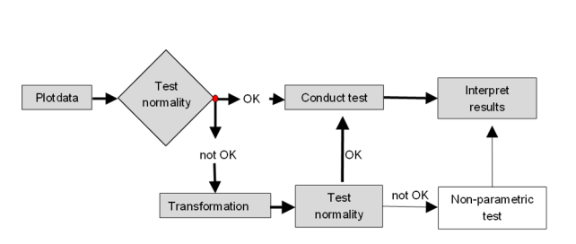

Work-flow for group comparisons (one or two groups)

#### Assessing normality using quantile-quantile-plots

- The main assumption for t-tests is that the data is normally distributed.
- Depending on the type of group comparison you need to assess normality for the following vector(s):
  - one sample test: data of the sample
  - two independent sample test: data vector of each group separately
  - paired-sample test: vector of differences between the two treatments for each experimental unit
- We can, therefore, use `hist()` or `qqnorm(); qqline()`
- Suppose we want to test if the Culmen length differs between the sexes(penguins dataset)
  - Let’s test normality of the outcome variable “culmen length”

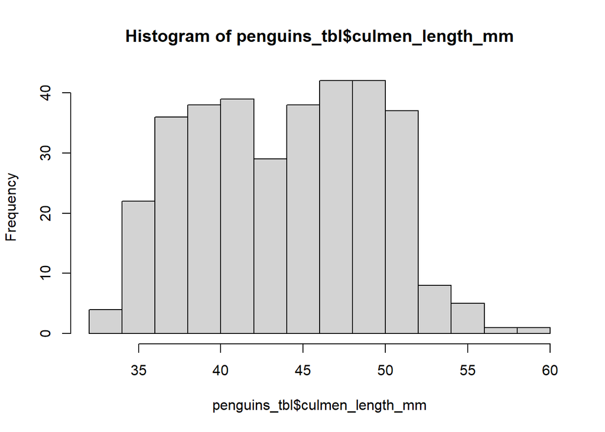

```r
hist(penguins_tbl$culmen_length_mm)
```

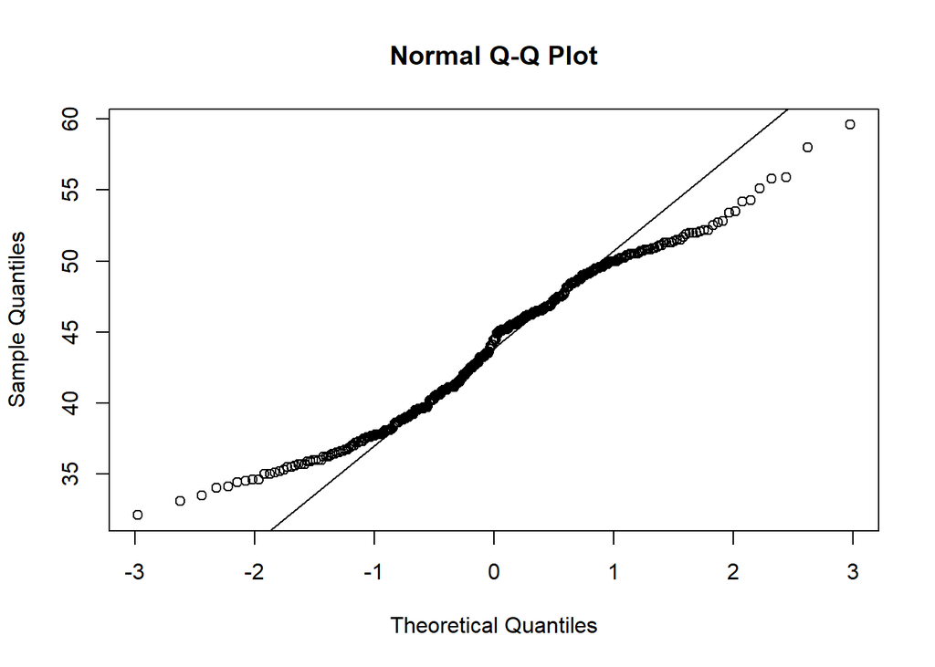

```r
qqnorm(penguins_tbl$culmen_length_mm); qqline(penguins_tbl$culmen_length_mm)
```

### Using t-test with R

- T-test are calculated using the command `t.test()`

#### One-sample t-test

- An example in which we want to test whether average human height is 1.77m. This is our data:

```r
height <- c(1.43,1.75,1.85,1.74,1.65,1.83,1.91,1.52,1.92,1.83)
```

- Note: the alternative hypothesis is that average human height is significantly different from 1.77m. We declare the model in the following way, to obtain the following output:

```r
t.test(height, mu = 1.77)
```

```
##
##  One Sample t-test
##
## data:  height
## t = -0.52046, df = 9, p-value = 0.6153
## alternative hypothesis: true mean is not equal to 1.77
## 95 percent confidence interval:
##  1.625646 1.860354
## sample estimates:
## mean of x
##     1.743
```

#### Two independent sample t-test

- We use the example of dispersal distance in male and female butterflies. This is your data:

```r
distance <- c(3,5,5,4,5,3,1,2,2,3)
sex <- c("male","male","male","male","male","female","female","female","female","female")
```

- Before running the test, it is important to consider your alternative hypothesis, specifically whether you want to run a one-tailed or two-tailed test.
  - If no alternative hypothesis is specified, the command will assume a two-tailed test.
- The two-sample t-test has a second assumption in addition to the **normality of the data**: **equal variance in the two samples**.
  - If the variances are assumed to be equal, this must be specified using the argument `var.equal = TRUE`, otherwise Welch´s t-test that does not assume equal variances is automatically used when needed. Here we assume equal variances and perform a two-tailed test.
    - To test for equality of variance, use the fn `var.test()`.
      - Ho: Variances are equal; H1: Variances differ

```r
t.test(distance ~ sex, var.equal = TRUE)
```

```
##
##  Two Sample t-test
##
## data:  distance by sex
## t = -4.0166, df = 8, p-value = 0.003859
## alternative hypothesis: true difference in means between group female and group male is not equal to 0
## 95 percent confidence interval:
##  -3.4630505 -0.9369495
## sample estimates:
## mean in group female   mean in group male
##                  2.2                  4.4
```

- Conclusion: Thus, male butterflies dispersal is significantly different from female butterflies.
- We can also specify a one-sided alternative hypothesis by adding the argument `alternative= “less”` or `alternative = “greater”` depending on which tail is to be tested:

```r
t.test(distance ~ sex, var.equal = TRUE, alternative="greater")
```

```
##
##  Two Sample t-test
##
## data:  distance by sex
## t = -4.0166, df = 8, p-value = 0.9981
## alternative hypothesis: true difference in means between group female and group male is greater than 0
## 95 percent confidence interval:
##  -3.218516       Inf
## sample estimates:
## mean in group female   mean in group male
##                  2.2                  4.4
```

- Conclusion: The results of these tests state that female dispersal distance is not significantly greater than male dispersal distance.

#### Paired sample t-test

- As an example of a paired test, we investigate whether the sleep of students is affected by an exam.
  - You ask 6 students how long they sleep the night before an exam and the night after an exam. These are the answers you get:

```r
sleep.before <- c(4,2,7,4,3,2)
sleep.after <- c(5,1,3,6,2,1)
```

- Here you simply run add the argument `paired=TRUE` to the command from the two-sampled test above.

```r
t.test(sleep.before, sleep.after, paired=TRUE)
```

```
##
##  Paired t-test
##
## data:  sleep.before and sleep.after
## t = 0.79057, df = 5, p-value = 0.465
## alternative hypothesis: true difference in means is not equal to 0
## 95 percent confidence interval:
##  -1.501038  2.834372
## sample estimates:
## mean of the differences
##               0.6666667
```

- Well, this test is NOT significant, and thus the data does not support an effect of exams on students sleeping time.

### Non-parametric alternatives

- Perhaps, the normality assumption is not satisfied even after transformations, then use nonparametrics tests equivalent to the parametric tests.
  - These include one-sample, two-sample (also names Mann Whitney-U test) and paired alternatives, all available through the command `wilcox.test()`.

### Cross-tabulation and the Chi-square test

- Suppose, we wish to test whether the two grouping variables are independent.
  - One of the most common ways to analyze contingency tables is with the $χ^2$ -test (Chi-square test).
    - Example:

```r
chisq.test(penguins_tbl$species, penguins_tbl$sex)
```

```
## Warning in chisq.test(penguins_tbl$species, penguins_tbl$sex): Chi-squared
## approximation may be incorrect
```

```
##
##  Pearson's Chi-squared test
##
## data:  penguins_tbl$species and penguins_tbl$sex
## X-squared = 1.8372, df = 4, p-value = 0.7657
```

- Warning; some levels have less than 5 count hence best to use fisher exact test.

```r
fisher.test(penguins_tbl$species, penguins_tbl$sex)
```

```
##
##  Fisher's Exact Test for Count Data
##
## data:  penguins_tbl$species and penguins_tbl$sex
## p-value = 0.9051
## alternative hypothesis: two.sided
```

### Introduce regression models: linear and logistics regression models

- Linear regression models are used to assess the association between a continuous outcome variables with dependent variables(can be discrete or continuous).
  - `lm(y~x)`
  - Must perform model diagnostics to ensure the model assumptions have been satisfied.
    - Independence
    - normality of the outcome variable
    - constant variance
- Logistic regression models are used when the response variable is a binary variable, again the dependent variables can be of any time.
  - `glm()`
    - Specify family: `logit`
  - Over-dispersion is expected because:
    - outcome variable is on the [0,1] scale while the dependent variables are on real line scale.